# Pokemon Base Stats: Powercreep and Design Decisions Throughout the Generations

#### Jonah McGlynn

You would be hardpressed to find someone who isn't aware of pokemon, whether they grew up watching the show and playing the games, seen the giant pikachu baloon on Thankgiving day, or have vaguely heard that the most recent games weren't all that great. Pokemon has been around since 1996 and has been releasing games continuously ever since, with the most recent games coming out just this past month. The games are divided into generations, of which Scarlet and Violet, the ones that came out last month, mark the beginning of the 9th. Each generation is defined by the new set of Pokemon they introduce, this can be as low as 78 new Pokemon or as high as 151. With so many Pokemon, it is inevitable that some end up better than others, however, some people make the argument that Pokemon has undergone powercreep over the years.

Powercreep is defined as the gradual unbalancing of a game due to successive releases of new content, leaving the older ones underpowered. In this case it would mean that new pokemon that are released are on average more powerful than those from earlier generations. But how do we define a more powerful pokemon? Pokemon have many stats that determine how they perform. They have stats for Health, Attack, Defense, Sp. Attack, Sp. Defense, and Speed. When playing the game how these grow can seem random, and it is intentionally designed to be so with complicating factors that we won't discuss in depth like EVs, IVs, and natures. However there is a fundamental driving force intrinsic to each Pokemon that determines how they develop. These are called base stats, they correspond to each of the stats discussed before, the higher the base stat, the higher the growth rate, and potential maximum a given stat can be. So a more powerful pokemo can generally be described as a pokemon with a higher base stat total. In order to determine whether or not powercreep is actually occuring we must observe base stat totals over the generations to see if and how they improve.

Another argument occasionally made is that certain generations tend to introduce pokemon with a tendency towards certain stats. It, for example, is often said that generation 4 is a slow and bulky generation as it is percieved as having a lot of pokemon with low speed and high defenses compared to other generations. In order to test the truth about this, we can look at the averages for each generation and using statistics make decisions about whether there is any significant differences between the generations for given stat types (offensive, defensive, and speed).

In order to get this data I found a dataset using kaggle, unfortunately I had trouble scraping it directly from python so I am putting a link of it here: https://www.kaggle.com/datasets/mariotormo/complete-pokemon-dataset-updated-090420

# 1. Powercreep

Here we define all the modules and other imports we will use throughout this tutorial. We also take the csv file taken from the link above and read it into a dataframe so we may use the data. It is printed for your convenience.

```python
import pandas as pd
import seaborn as sb
import numpy as np
import matplotlib.pyplot as plt
from sklearn.linear_model import LinearRegression
import statsmodels.api as sm
import statsmodels.formula.api as smf
from scipy import stats
import requests
from bs4 import BeautifulSoup
from statsmodels.stats.multicomp import pairwise_tukeyhsd

pokeData = pd.read_csv("~/notebooks/pokedex_(Update_05.20).csv")
pokeData
```

|  | Unnamed: 0 | pokedex_number | name | german_name | japanese_name | generation | status | species | type_number | type_1 | ... | against_ground | against_flying | against_psychic | against_bug | against_rock | against_ghost | against_dragon | against_dark | against_steel | against_fairy |
| --- | --- | --- | --- | --- | --- | --- | --- | --- | --- | --- | --- | --- | --- | --- | --- | --- | --- | --- | --- | --- | --- |
| 0 | 0 | 1 | Bulbasaur | Bisasam | フシギダネ (Fushigidane) | 1 | Normal | Seed Pokémon | 2 | Grass | ... | 1.0 | 2.0 | 2.0 | 1.00 | 1.00 | 1.0 | 1.0 | 1.0 | 1.0 | 0.5 |
| 1 | 1 | 2 | Ivysaur | Bisaknosp | フシギソウ (Fushigisou) | 1 | Normal | Seed Pokémon | 2 | Grass | ... | 1.0 | 2.0 | 2.0 | 1.00 | 1.00 | 1.0 | 1.0 | 1.0 | 1.0 | 0.5 |
| 2 | 2 | 3 | Venusaur | Bisaflor | フシギバナ (Fushigibana) | 1 | Normal | Seed Pokémon | 2 | Grass | ... | 1.0 | 2.0 | 2.0 | 1.00 | 1.00 | 1.0 | 1.0 | 1.0 | 1.0 | 0.5 |
| 3 | 3 | 3 | Mega Venusaur | Bisaflor | フシギバナ (Fushigibana) | 1 | Normal | Seed Pokémon | 2 | Grass | ... | 1.0 | 2.0 | 2.0 | 1.00 | 1.00 | 1.0 | 1.0 | 1.0 | 1.0 | 0.5 |
| 4 | 4 | 4 | Charmander | Glumanda | ヒトカゲ (Hitokage) | 1 | Normal | Lizard Pokémon | 1 | Fire | ... | 2.0 | 1.0 | 1.0 | 0.50 | 2.00 | 1.0 | 1.0 | 1.0 | 0.5 | 0.5 |
| ... | ... | ... | ... | ... | ... | ... | ... | ... | ... | ... | ... | ... | ... | ... | ... | ... | ... | ... | ... | ... | ... |
| 1023 | 1023 | 888 | Zacian Hero of Many Battles | NaN | NaN | 8 | Legendary | Warrior Pokémon | 1 | Fairy | ... | 1.0 | 1.0 | 1.0 | 0.50 | 1.00 | 1.0 | 0.0 | 0.5 | 2.0 | 1.0 |
| 1024 | 1024 | 889 | Zamazenta Crowned Shield | NaN | NaN | 8 | Legendary | Warrior Pokémon | 2 | Fighting | ... | 2.0 | 1.0 | 1.0 | 0.25 | 0.25 | 1.0 | 0.5 | 0.5 | 0.5 | 1.0 |
| 1025 | 1025 | 889 | Zamazenta Hero of Many Battles | NaN | NaN | 8 | Legendary | Warrior Pokémon | 1 | Fighting | ... | 1.0 | 2.0 | 2.0 | 0.50 | 0.50 | 1.0 | 1.0 | 0.5 | 1.0 | 2.0 |
| 1026 | 1026 | 890 | Eternatus | NaN | NaN | 8 | Legendary | Gigantic Pokémon | 2 | Poison | ... | 2.0 | 1.0 | 2.0 | 0.50 | 1.00 | 1.0 | 2.0 | 1.0 | 1.0 | 1.0 |
| 1027 | 1027 | 890 | Eternatus Eternamax | NaN | NaN | 8 | Legendary | Gigantic Pokémon | 2 | Poison | ... | 2.0 | 1.0 | 2.0 | 0.50 | 1.00 | 1.0 | 2.0 | 1.0 | 1.0 | 1.0 |

1028 rows × 51 columns

Next we take a closer look at the data and notice that there are a lot of columns that are not relevant to what we are looking into, but could perhaps be useful for a different project. Furthermore, there appear to be cases where certain stat totals are labeled erroneously, at least for my purposes. For example, Mega Pokemon, a short lived mechanic unique to generations 6 and 7 that gave certain pokemon temporary evolutions, are listed under the generation of the pokemon that evolved. However, these evolutions were not introduced until generation 6, so we should not consider them for the analysis of generations 1-5. We have similar cases for Alolan and Galarian pokemon.

```python
pokeData.columns
```

```
Index(['Unnamed: 0', 'pokedex_number', 'name', 'german_name', 'japanese_name',
       'generation', 'status', 'species', 'type_number', 'type_1', 'type_2',
       'height_m', 'weight_kg', 'abilities_number', 'ability_1', 'ability_2',
       'ability_hidden', 'total_points', 'hp', 'attack', 'defense',
       'sp_attack', 'sp_defense', 'speed', 'catch_rate', 'base_friendship',
       'base_experience', 'growth_rate', 'egg_type_number', 'egg_type_1',
       'egg_type_2', 'percentage_male', 'egg_cycles', 'against_normal',
       'against_fire', 'against_water', 'against_electric', 'against_grass',
       'against_ice', 'against_fight', 'against_poison', 'against_ground',
       'against_flying', 'against_psychic', 'against_bug', 'against_rock',
       'against_ghost', 'against_dragon', 'against_dark', 'against_steel',
       'against_fairy'],
      dtype='object')
```

Next we should clean up the data. I chose to remove columns I wasn't going to use, I did it this way because it was easy to copy and paste much of it into the dataset. However, another way to do it is to simply set a list of columns you desire to keep. I also dropped the last data point as it represents a temporary (5 turn) transformation that any pokemon can undergo in generation 8 that massively increases the pokemons stats, however it has no place here as no other pokemon has its max form recorded and I believe it to fail to accurately describe the pokemon itself since the transformation is only temporary (Megas last an entire battle).

```python
pokeData = pokeData.drop(["german_name","japanese_name","Unnamed: 0", "species",'base_friendship',\
       'base_experience', 'growth_rate', 'egg_type_number', 'egg_type_1',\
       'egg_type_2', 'percentage_male', 'egg_cycles', 'against_normal',\
       'against_fire', 'against_water', 'against_electric', 'against_grass',\
       'against_ice', 'against_fight', 'against_poison', 'against_ground',\
       'against_flying', 'against_psychic', 'against_bug', 'against_rock',\
       'against_ghost', 'against_dragon', 'against_dark', 'against_steel',\
       'against_fairy', 'height_m', 'weight_kg', 'abilities_number','status'], axis = 1)
pokeData = pokeData.drop(1027,axis = 0)
```

To continue to clean the data I found all locations where a Pokemon was assigned a generation it wasn't introduced in. This would happen when a new form of an existing Pokemon was introduced in a later generation. It is important to note and reassign them as they often have different properties compared to the original versions and may pollute the analysis. Fortunately this is rally only an issue for generations 6, 7, and 8 which introduced Megas, Alolan forms, and Galarian forms respectively.

```python
pokeData.loc[pokeData["name"].str.contains("Mega "), "generation"] = 6
pokeData.loc[pokeData["name"].str.contains("Primal "), "generation"] = 6
pokeData.loc[pokeData["name"].str.contains("Alolan "), "generation"] = 7
pokeData.loc[pokeData["name"].str.contains("Galarian "), "generation"] = 8
```

I initially elected to try a scatter plot, however, it is not quite suitable for this application. It gives us limited uderstanding of where the spread and mean lie but it does not show us what the distribution looks like.

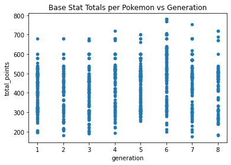

```python
pokeData.plot.scatter(x = "generation", y = "total_points", title = "Base Stat Totals per Pokemon vs Generation")
```

Instead I made a violin plot. A violin plot is useful as it shows the distribution and where the mean lies. Now there are some problems with the distribution found, but more on that later.

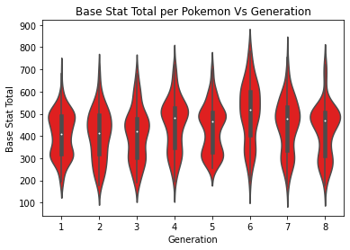

```python
fig, ax = plt.subplots()
sb.violinplot(data=pokeData, x="generation", y="total_points", color = "red")
ax.set_xlabel("Generation")
ax.set_ylabel("Base Stat Total")
ax.set_title("Base Stat Total per Pokemon Vs Generation")
```

We can almost convince ourselves, through knowledge of the locations of the means and knowing where the data is most highly concentrated, that we have a linear relation between generationa and BST. We attempt a Linear Regression using scikits Linear Regression tools, we then plot the line over the original violin plot. The line appears to fit the means rather well.

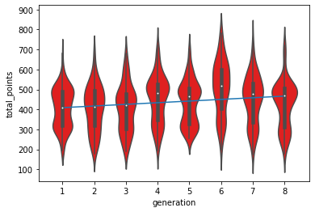

```python
X = pokeData[["generation"]]
y = pokeData["total_points"]
reg = LinearRegression().fit(pokeData[["generation"]], pokeData[["total_points"]])
sb.violinplot(data=pokeData, x="generation", y="total_points", color = "red")
plt.plot(pokeData["generation"]-1, reg.predict(X))
```

Although a line has been found we need to test if the supposed increase is significant. Using statsmodel api we use the least squares method to test the hypothesis that the slope is significantly different from 0 for the formula relating Generation number to base stat increase (we assume a relatively constant increase per generation on avergae).

The analysis shows an r squared value of only .024 meaning the line does not explain the variation very well, this is understandable however due to the massive variation within a generation, and it does not necessarily invalidate our model. Looking further down we see the coefficients for the regression being 400.732 as the intercepet and 8.2623 as the slope, which means (assuming that we can find the coefficient is statistically significantly different from 0), that the average base stat increase is about 8.2623 per generation.

We see the slope (next to generation as slope is the coefficient of generation in the formula) has a t value of 5, very high, which corresponds to a p value of 0. Since the p value is so low we can reject the null hypothesis. As such given the model is valid, we see about an 8.2 point increase in base stats per generation.

```python
mod = smf.ols(formula='total_points ~ generation', data = pokeData)
res = mod.fit()
print(res.summary())
print("")
```

```
                            OLS Regression Results
==============================================================================
Dep. Variable:           total_points   R-squared:                       0.024
Model:                            OLS   Adj. R-squared:                  0.023
Method:                 Least Squares   F-statistic:                     25.02
Date:                Sat, 17 Dec 2022   Prob (F-statistic):           6.67e-07
Time:                        04:53:09   Log-Likelihood:                -6359.5
No. Observations:                1027   AIC:                         1.272e+04
Df Residuals:                    1025   BIC:                         1.273e+04
Df Model:                           1
Covariance Type:            nonrobust
==============================================================================
                 coef    std err          t      P>|t|      [0.025      0.975]
------------------------------------------------------------------------------
Intercept    400.7320      8.121     49.347      0.000     384.797     416.667
generation     8.2623      1.652      5.002      0.000       5.021      11.503
==============================================================================
Omnibus:                       20.193   Durbin-Watson:                   1.566
Prob(Omnibus):                  0.000   Jarque-Bera (JB):               11.417
Skew:                           0.037   Prob(JB):                      0.00332
Kurtosis:                       2.489   Cond. No.                         11.2
==============================================================================

Notes:
[1] Standard Errors assume that the covariance matrix of the errors is correctly specified.
```

For fun, we can try to predict the average base stat total for generation 9, we can either put it into the formuala or using the predict functon. Though this isnt technically valid due to extrapolation errors, we can not make predictions for data we know nothing about.

```python
print("The predicted average base stat total for generation 9 is", reg.predict([[9]])[0][0])
```

```
The predicted average base stat total for generation 9 is 475.0925258587123
```

To check validity of our model we check the residuals, if the disributions of the residuals are approximately normal and centered around 0 the linear model assumptions are valid. Unfortunately, while the means are (more or less) centered around 0, the distributions are not normal as they are not unimodal. Our data may not be valid anymore.

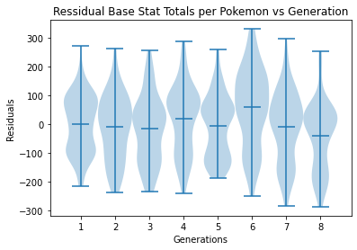

```python
pokeData["total_res"] = pokeData["total_points"] - reg.predict(X).reshape(1,-1)[0]
fig, ax = plt.subplots()
ax.violinplot(pokeData.groupby("generation")["total_res"].apply(list),[1,2,3,4,5,6,7,8] ,widths=1,showmeans=True)
ax.set_xlabel("Generations")
ax.set_ylabel("Residuals")
ax.set_title("Ressidual Base Stat Totals per Pokemon vs Generation")
```

It appears that in each generation we may unwittingly have put in two major groups with significantly different properties, fully evolved Pokemon and not fully evolved Pokemon. In order to remedy this I scraped more data from online, namely I gathered a list of all pokemon that were fully evolved and their pokedex number from bulbapedia and stored it as a dataframe. I did this using BeautifulSoup and obtained the html table.

```python
r = requests.get("https://bulbapedia.bulbagarden.net/wiki/List_of_fully_evolved_Pok%C3%A9mon_by_base_stats")
root = BeautifulSoup(r.content)
fullyEvolved = pd.read_html(root.find("table").prettify())[0]
fullyEvolved
```

|  | # | Unnamed: 1 | Pokémon | HP | Attack | Defense | Sp. Attack | Sp. Defense | Speed | Total | Average |
| --- | --- | --- | --- | --- | --- | --- | --- | --- | --- | --- | --- |
| 0 | 003 | NaN | Venusaur | 80 | 82 | 83 | 100 | 100 | 80 | 525 | 87.50 |
| 1 | 003 | NaN | Venusaur (Mega Venusaur) | 80 | 100 | 123 | 122 | 120 | 80 | 625 | 104.17 |
| 2 | 006 | NaN | Charizard | 78 | 84 | 78 | 109 | 85 | 100 | 534 | 89.00 |
| 3 | 006 | NaN | Charizard (Mega Charizard X) | 78 | 130 | 111 | 130 | 85 | 100 | 634 | 105.67 |
| 4 | 006 | NaN | Charizard (Mega Charizard Y) | 78 | 104 | 78 | 159 | 115 | 100 | 634 | 105.67 |
| ... | ... | ... | ... | ... | ... | ... | ... | ... | ... | ... | ... |
| 686 | ' | NaN | Chi-Yu | 55 | 80 | 80 | 135 | 120 | 100 | 570 | 95.00 |
| 687 | ' | NaN | Roaring Moon | 105 | 139 | 71 | 55 | 101 | 119 | 590 | 98.33 |
| 688 | ' | NaN | Iron Valiant | 74 | 130 | 90 | 120 | 60 | 116 | 590 | 98.33 |
| 689 | ' | NaN | Koraidon | 100 | 135 | 115 | 85 | 100 | 135 | 670 | 111.67 |
| 690 | ' | NaN | Miraidon | 100 | 85 | 100 | 135 | 115 | 135 | 670 | 111.67 |

691 rows × 11 columns

I want to match pokemon here by the pokedex number but to do that I need to make the pokedex number an int. To do so I needed to remove any row that had invalid data. All the pokemon with invalid data are part of the new generation that isn't in my previous dataset anyway, so I kept only rows before the beginning of the new generation.

```python
fullyEvolved = fullyEvolved[fullyEvolved.index < 624]
fullyEvolved
```

|  | # | Unnamed: 1 | Pokémon | HP | Attack | Defense | Sp. Attack | Sp. Defense | Speed | Total | Average |
| --- | --- | --- | --- | --- | --- | --- | --- | --- | --- | --- | --- |
| 0 | 003 | NaN | Venusaur | 80 | 82 | 83 | 100 | 100 | 80 | 525 | 87.50 |
| 1 | 003 | NaN | Venusaur (Mega Venusaur) | 80 | 100 | 123 | 122 | 120 | 80 | 625 | 104.17 |
| 2 | 006 | NaN | Charizard | 78 | 84 | 78 | 109 | 85 | 100 | 534 | 89.00 |
| 3 | 006 | NaN | Charizard (Mega Charizard X) | 78 | 130 | 111 | 130 | 85 | 100 | 634 | 105.67 |
| 4 | 006 | NaN | Charizard (Mega Charizard Y) | 78 | 104 | 78 | 159 | 115 | 100 | 634 | 105.67 |
| ... | ... | ... | ... | ... | ... | ... | ... | ... | ... | ... | ... |
| 619 | 902 | NaN | Basculegion (Female) | 120 | 92 | 65 | 100 | 75 | 78 | 530 | 88.33 |
| 620 | 903 | NaN | Sneasler | 80 | 130 | 60 | 40 | 80 | 120 | 510 | 85.00 |
| 621 | 904 | NaN | Overqwil | 85 | 115 | 95 | 65 | 65 | 85 | 510 | 85.00 |
| 622 | 905 | NaN | Enamorus (Incarnate Forme) | 74 | 115 | 70 | 135 | 80 | 106 | 580 | 96.67 |
| 623 | 905 | NaN | Enamorus (Therian Forme) | 74 | 115 | 110 | 135 | 100 | 46 | 580 | 96.67 |

624 rows × 11 columns

I stored the pokedex numbers as a new series and casted them as type int. I then checked whether a given pokedex number in the dataframe was in the new series. I added a new column to denote where this was the case. I also did the same for any pokemon that should have been but were not on the fully evolved list (as they got new evoutions in later generations) by hand.

```python
FE = fullyEvolved["#"].astype("int")
pokeData["is_FE"] = pokeData["pokedex_number"].isin(FE)
pokeData.loc[pokeData["name"].isin(["Golbat","Onix","Magneton",'Lickitung',"Rhydon","Chansey","Seadra","Scyther",\
                                    "Electabuzz","Magmar","Porygon","Porygon2","Togetic","Aipom","Yanma","Murkrow",\
                                    "Misdreavus", "Gligar", "Sneasel", "Piloswine","Nosepass","Roselia", "Dusclops"]), "is_FE"] = True
```

I created two new data frames for the fully evolved pokemon as well as one for the same but without megas. With a little future sight I know the resultant distributions are approximately normal with similar variances so I decided this time to use an ANOVA to check whether the average BST could be said to be the same through each generation. In each case )for noMega and onlyFE the p value was much less than one denoting that the BSTs were significantly different from each other throughout the generations

```python
onlyFE = pokeData[pokeData["is_FE"]]
noMega = onlyFE[onlyFE["name"].str.contains("Mega ") == False]
noMega = noMega[noMega["name"].str.contains("Primal ") == False]

print("ANOVA of only final evolutions")
modelFE = smf.ols('total_points ~ C(generation)', data=onlyFE).fit()
anova_table = sm.stats.anova_lm(modelFE, typ=2)
print(anova_table)

print("")
print("ANOVA of only final evolutions without including Mega Pokemon")
modelNM = smf.ols('total_points ~ C(generation)', data=noMega).fit()
anova_table = sm.stats.anova_lm(modelNM, typ=2)
print(anova_table)
```

```
ANOVA of only final evolutions
                     sum_sq     df          F        PR(>F)
C(generation)  6.481885e+05    7.0  16.963262  1.467564e-20
Residual       3.362595e+06  616.0        NaN           NaN

ANOVA of only final evolutions without including Mega Pokemon
                     sum_sq     df         F        PR(>F)
C(generation)  2.139841e+05    7.0  6.047996  8.072987e-07
Residual       2.860806e+06  566.0       NaN           NaN
```

I repeated my steps as I did for all the pokemon for only Final Evolutions and the results are chronicled below

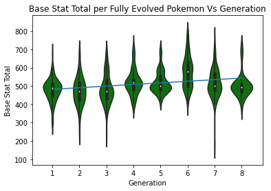

```python
fig, ax1 = plt.subplots()
sb.violinplot(data=onlyFE, x="generation", y="total_points", color = "green")
X = onlyFE[["generation"]]
y = onlyFE["total_points"]
regFE = LinearRegression().fit(onlyFE[["generation"]], onlyFE[["total_points"]])
ax1.plot(onlyFE["generation"]-1, regFE.predict(X))
ax1.set_xlabel("Generation")
ax1.set_ylabel("Base Stat Total")
ax1.set_title("Base Stat Total per Fully Evolved Pokemon Vs Generation")
```

```python
mod = smf.ols(formula='total_points ~ generation', data = onlyFE)
res = mod.fit()
print(res.summary())
```

```
                            OLS Regression Results
==============================================================================
Dep. Variable:           total_points   R-squared:                       0.059
Model:                            OLS   Adj. R-squared:                  0.058
Method:                 Least Squares   F-statistic:                     39.27
Date:                Sat, 17 Dec 2022   Prob (F-statistic):           6.90e-10
Time:                        04:53:11   Log-Likelihood:                -3602.0
No. Observations:                 624   AIC:                             7208.
Df Residuals:                     622   BIC:                             7217.
Df Model:                           1
Covariance Type:            nonrobust
==============================================================================
                 coef    std err          t      P>|t|      [0.025      0.975]
------------------------------------------------------------------------------
Intercept    473.2863      7.051     67.121      0.000     459.439     487.133
generation     8.8169      1.407      6.267      0.000       6.054      11.580
==============================================================================
Omnibus:                       38.839   Durbin-Watson:                   0.789
Prob(Omnibus):                  0.000   Jarque-Bera (JB):               65.655
Skew:                           0.441   Prob(JB):                     5.54e-15
Kurtosis:                       4.321   Cond. No.                         11.7
==============================================================================

Notes:
[1] Standard Errors assume that the covariance matrix of the errors is correctly specified.
```

```python
print("The predicted average base stat total for generation 9 is", regFE.predict([[9]])[0][0])
```

```
The predicted average base stat total for generation 9 is 552.6381713318553
```

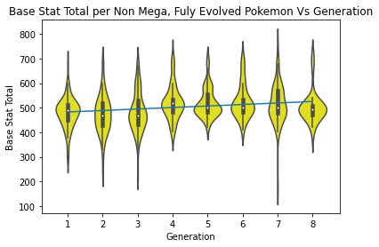

```python
fig, ax2 = plt.subplots()
sb.violinplot(data=noMega, x="generation", y="total_points", color = "yellow")
X = noMega[["generation"]]
y = noMega["total_points"]
regNM = LinearRegression().fit(noMega[["generation"]], noMega[["total_points"]])
ax2.plot(noMega["generation"]-1, regNM.predict(X))
ax2.set_xlabel("Generation")
ax2.set_ylabel("Base Stat Total")
ax2.set_title("Base Stat Total per Non Mega, Fuly Evolved Pokemon Vs Generation")
```

```python
mod = smf.ols(formula='total_points ~ (generation)', data = noMega)
res = mod.fit()
print(res.summary())
```

```
                            OLS Regression Results
==============================================================================
Dep. Variable:           total_points   R-squared:                       0.036
Model:                            OLS   Adj. R-squared:                  0.034
Method:                 Least Squares   F-statistic:                     21.11
Date:                Sat, 17 Dec 2022   Prob (F-statistic):           5.33e-06
Time:                        04:53:11   Log-Likelihood:                -3268.3
No. Observations:                 574   AIC:                             6541.
Df Residuals:                     572   BIC:                             6549.
Df Model:                           1
Covariance Type:            nonrobust
==============================================================================
                 coef    std err          t      P>|t|      [0.025      0.975]
------------------------------------------------------------------------------
Intercept    476.6329      6.527     73.022      0.000     463.813     489.453
generation     6.1009      1.328      4.595      0.000       3.493       8.709
==============================================================================
Omnibus:                       36.681   Durbin-Watson:                   0.806
Prob(Omnibus):                  0.000   Jarque-Bera (JB):               83.400
Skew:                           0.346   Prob(JB):                     7.76e-19
Kurtosis:                       4.735   Cond. No.                         11.0
==============================================================================

Notes:
[1] Standard Errors assume that the covariance matrix of the errors is correctly specified.
```

```python
print("The predicted average base stat total for generation 9 is", regFE.predict([[9]])[0][0])
```

```
The predicted average base stat total for generation 9 is 552.6381713318553
```

The results are overall similar to those found for all Pokemon, but with better residuals as can be gleaned from the distributions even without needing to plot the residuals. For Fully Evolved we found a better r square and a larger intercept and slope which was as expected as we had overall higher values to work with since FE pokemon have better BST than NFE pokemon. We found a similar case for without megas, though without the megas the average increase per generation drops significantly. The megas truly were a powerful force. In all cases the p value was about 0 so we can reject the null hypothesis that the slope was not significantly differenet from 0.

# 2. Design Decisions

Now we would like to determine if there is any significant different in individual stat totals for each generations, I decided that would get very cluttered very fast howver, I decided to see if there was any differnece in the avergae offense, defense, and speed between generations and between which generations they are significant.

First I decided to explore this. I plotted average attack and special attack combined to get average offensive power, average hp, defense, and sp defense to get average defense, and speed for, well, speed. I chose to use a bar graph as I felt it gave a good visualization for differences in mean. I did this for all pokemon and for no megas as, as previously shown, the distributionof stats in all pokemon is not normal. I chose no mega as choosing all FE would only have buffed gen 6 without doing much else, I felt this was a better way of showing generational philosophies for pokemon individually rather than battle buffs.

```
<BarContainer object of 8 artists>
```

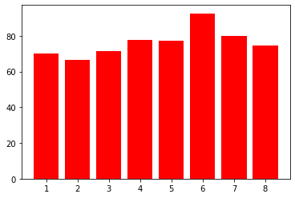

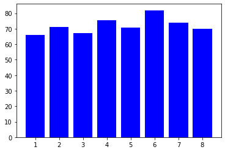

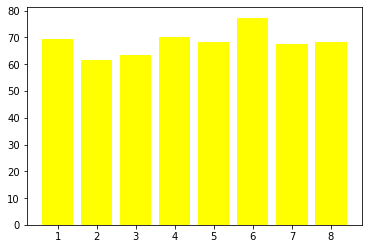

```python
statsTotalData = pokeData.groupby("generation")

plt.bar(x = [1,2,3,4,5,6,7,8], height = (statsTotalData["attack"].mean()+statsTotalData["sp_attack"].mean())/2, color = "red")
plt.subplots()
plt.bar(x = [1,2,3,4,5,6,7,8], height = (statsTotalData["defense"].mean()+statsTotalData["sp_defense"].mean()+statsTotalData["hp"].mean())/3, color = "blue")
plt.subplots()
plt.bar(x = [1,2,3,4,5,6,7,8], height = statsTotalData["speed"].mean(), color = "yellow")
```

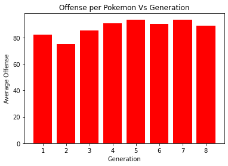

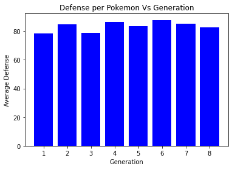

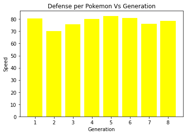

```python
statsTotalData = noMega.groupby("generation")

fig,ax = plt.subplots()
plt.bar(x = [1,2,3,4,5,6,7,8], height = (statsTotalData["attack"].mean()+statsTotalData["sp_attack"].mean())/2, color = "red")
ax.set_xlabel("Generation")
ax.set_ylabel("Average Offense")
ax.set_title("Offense per Pokemon Vs Generation")

fig,ax = plt.subplots()
plt.bar(x = [1,2,3,4,5,6,7,8], height = (statsTotalData["defense"].mean()+statsTotalData["sp_defense"].mean()+statsTotalData["hp"].mean())/3, color = "blue")
ax.set_xlabel("Generation")
ax.set_ylabel("Average Defense")
ax.set_title("Defense per Pokemon Vs Generation")

fig, ax = plt.subplots()
plt.bar([1,2,3,4,5,6,7,8], statsTotalData["speed"].mean(), color = "yellow")
ax.set_xlabel("Generation")
ax.set_ylabel("Speed")
ax.set_title("Defense per Pokemon Vs Generation")
```

Finally I did an ANOVA analysis for each stat, if the p value was less than .05 there was a significant diference in means across generations, which this time are treated as treatments. If so I followed up with a Tukey HSD, whichi is like a t-test but design to test between many pairs such that it accounts for errors from repeated t test. It is chronicled below the ANOVA table. Anywhere the final column says true, the two generations listed on the right can be said to have a statistically significnt difference between the stat being examined. As the null hypothesis saying they have the same mean given the variation within the set is rejected.

```python
noMega["ave_attack"] = (noMega["attack"]+noMega["sp_attack"])/2
noMega["ave_defense"] = (noMega["defense"]+noMega["sp_defense"]+noMega["hp"])/3


print("ANOVA of only final evolutions without including Mega Pokemon for average attack")
modelNM = smf.ols('ave_attack ~ C(generation)', data=noMega).fit()
anova_table = sm.stats.anova_lm(modelNM, typ=2)
print(anova_table)
print("")


tukey = pairwise_tukeyhsd(endog=noMega['ave_attack'], groups=noMega['generation'],alpha=0.05)
print(tukey)
print("")
```

```
ANOVA of only final evolutions without including Mega Pokemon for average attack
                      sum_sq     df         F        PR(>F)
C(generation)   19072.041837    7.0  6.509633  2.119917e-07
Residual       236896.744313  566.0       NaN           NaN

 Multiple Comparison of Means - Tukey HSD, FWER=0.05
=====================================================
group1 group2 meandiff p-adj   lower    upper  reject
-----------------------------------------------------
     1      2  -7.0909  0.461 -17.6895  3.5077  False
     1      3   3.2712    0.9  -6.4198 12.9621  False
     1      4    8.791 0.1203  -1.0569 18.6389  False
     1      5  11.4128  0.007   1.8895 20.9361   True
     1      6   8.2544 0.3476  -3.1075 19.6164  False
     1      7  11.1466 0.0148   1.2652 21.0281   True
```

[output cut: 23 more lines]

```python
print("ANOVA of only final evolutions without including Mega Pokemon for average defense")
modelNM = smf.ols('ave_defense ~ C(generation)', data=noMega).fit()
anova_table = sm.stats.anova_lm(modelNM, typ=2)
print(anova_table)
print("")

tukey = pairwise_tukeyhsd(endog=noMega['ave_defense'], groups=noMega['generation'],alpha=0.05)
print(tukey)
print("")
```

```
ANOVA of only final evolutions without including Mega Pokemon for average defense
                      sum_sq     df         F    PR(>F)
C(generation)    5515.188009    7.0  2.868741  0.005972
Residual       155448.808894  566.0       NaN       NaN

 Multiple Comparison of Means - Tukey HSD, FWER=0.05
=====================================================
group1 group2 meandiff p-adj   lower    upper  reject
-----------------------------------------------------
     1      2   6.3355 0.3263  -2.2499 14.9209  False
     1      3   0.6152    0.9  -7.2349  8.4654  False
     1      4   7.8922 0.0549  -0.0852 15.8695  False
     1      5   5.1828 0.4555  -2.5316 12.8971  False
     1      6    9.458 0.0391   0.2542 18.6618   True
     1      7   6.5853 0.1961  -1.4192 14.5898  False
```

[output cut: 23 more lines]

```python
print("ANOVA of only final evolutions without including Mega Pokemon for speed")
modelNM = smf.ols('speed ~ C(generation)', data=noMega).fit()
anova_table = sm.stats.anova_lm(modelNM, typ=2)
print(anova_table)
print("")
```

```
ANOVA of only final evolutions without including Mega Pokemon for speed
                      sum_sq     df         F    PR(>F)
C(generation)    7658.562194    7.0  1.320934  0.237776
Residual       468796.812370  566.0       NaN       NaN
```

# Conclusion

As we have shown the slope for increase in base stat totals is always significantly different from 0, and the average new non mega fully evolved pokemon is shown to have an average increase of 6 point sover the previous generation. So if we base a pokemons power solely on its BST then powercreep is indeed occuring.

Further, it seems pokemon stat design is more similar among generations than is commonly believed. Average speed stats could not be shown to have a significant difference between generations, the only defenseive difference occured between generation 1 and 6, and offensely mostly showed that generation 2 was weaker than most of its peers.

A further step that could be taken into this would be to scrape pokemon tier listing for smogon rulesets (singles, tier are OU, UU, RU,...) to see if BST and perhaps types and abilities could predict the tiering and thus quality of a pokemon. W ecould test whether BST ACTUALLY correlates to a better pokeon this way. I would have done that for this project had I not been under such heavy time constraints from exams, other final projects, etc.